# Heart diseases

#### plot k-mean

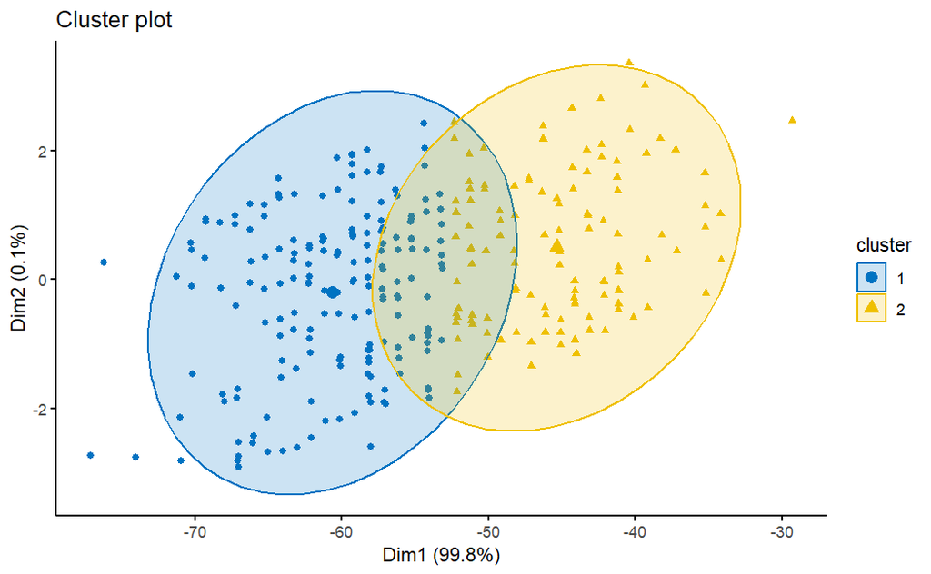

```r
fviz_cluster(list(data = dataset, cluster = km$cluster),
             ellipse.type = "norm", geom = "point", stand = FALSE,
             palette = "jco", ggtheme = theme_classic())
```

```r
sil <- silhouette(km$cluster, dist(dataset))
rownames(sil) <- rownames(dataset)
```

|  | cluster | size | ave.sil.width |
| --- | --- | --- | --- |
| 1 | 1 | 183 | 0.53 |
| 2 | 2 | 119 | 0.53 |

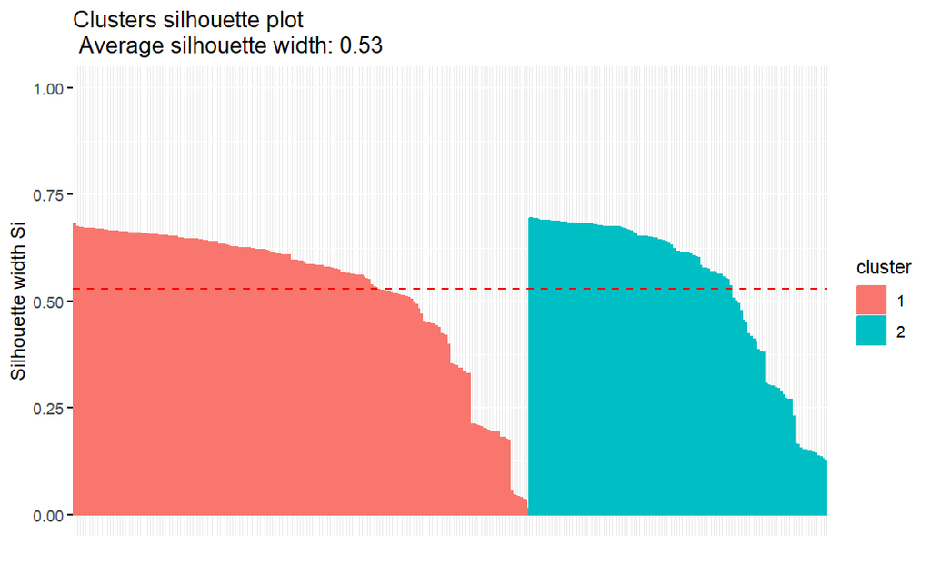

```r
fviz_silhouette(sil)
```

The average silhouette width of 0.53 suggests that the data points in a clustering analysis are well-matched to their assigned clusters and the clusters themselves are reasonably separated from each other. A positive average silhouette width indicates that, on average, the data points are well-clustered and have a higher similarity to their own cluster compared to other clusters.

#### Total within-cluster-sum of square

```r
km$tot.withinss
```

```
[1] 9211.318
```

```r
cluster_assignments <- c(km$cluster)
ground_truth_labels <- c(dataBeforC$target)

data <- data.frame(cluster = cluster_assignments, label = ground_truth_labels)

# Function to calculate BCubed precision and recall
calculate_bcubed_metrics <- function(data) {
  n <- nrow(data)
  precision_sum <- 0
  recall_sum <- 0

  for (i in 1:n) {
    cluster <- data$cluster[i]
    label <- data$label[i]

# Count the number of items from the same category within the same cluster
same_category_same_cluster <- sum(data$label[data$cluster == cluster] == label)

# Count the total number of items in the same cluster
total_same_cluster <- sum(data$cluster == cluster)

# Count the total number of items with the same category
total_same_category <- sum(data$label == label)

# Calculate precision and recall for the current item and add them to the sums
precision_sum <- precision_sum + same_category_same_cluster /total_same_cluster
recall_sum <- recall_sum + same_category_same_cluster / total_same_category
  }

  # Calculate average precision and recall
  precision <- precision_sum / n
  recall <- recall_sum / n

  return(list(precision = precision, recall = recall))
}

# Calculate BCubed precision and recall
metrics <- calculate_bcubed_metrics(data)

# Extract precision and recall from the metrics
precision <- metrics$precision
recall <- metrics$recall

# Print the results
cat("BCubed Precision:", precision, "\n")
```

```
BCubed Precision: 0.5347233
```

```r
cat("BCubed Recall:", recall, "\n")
```

```
BCubed Recall: 0.5523007
```

The Bcubed precision value indicates the percentage of correctly grouped data points in each cluster, with an average of approximately 53.47%. A higher precision value suggests a better ability of the clustering algorithm to assign similar data points to the same cluster while avoiding unrelated ones. On the other hand, the Bcubed recall value represents the percentage of relevant data points captured by the algorithm in each cluster, averaging around 55.23%. Higher recall values indicate the algorithm’s ability to include all the relevant data points in each cluster. In summary, the precision value is slightly lower than the recall value, indicating that the clustering algorithm may include some unrelated data points in a cluster, resulting in a slightly lower precision. However, it’s worth noting that the difference between precision and recall is relatively small.

#### calculate k-mean k=3

```r
km <- kmeans(dataset, 3, iter.max = 140 , algorithm="Lloyd", nstart=100)
km
```

```
K-means clustering with 3 clusters of sizes 136, 87, 79

Cluster means:
       age       sex        cp trestbps      chol   restecg   thalach     exang   oldpeak    slope        ca
1 55.43382 0.7205882 0.9191176 3.676471 0.4167425 0.5073529 0.5879546 0.3823529 0.1799099 1.382353 0.6691176
2 42.93103 0.7241379 1.0689655 3.068966 0.3673421 0.6091954 0.6902694 0.2298851 0.1047460 1.528736 0.2643678
3 65.32911 0.5696203 0.9240506 3.898734 0.4471921 0.4683544 0.5204368 0.3417722 0.2180482 1.278481 1.1012658
      thal
1 2.389706
2 2.229885
3 2.329114

Clustering vector:
  1   2   3   4   5   6   7   8   9  10  11  12  13  14  15  17  18  19  20  21  22  23  24  25  26  27  28  29
  1   1   3   3   3   1   1   1   2   1   3   2   2   1   1   1   1   1   1   1   3   2   3   2   3   2   1   1
```

[output cut: 29 more lines]

#### plot k-mean

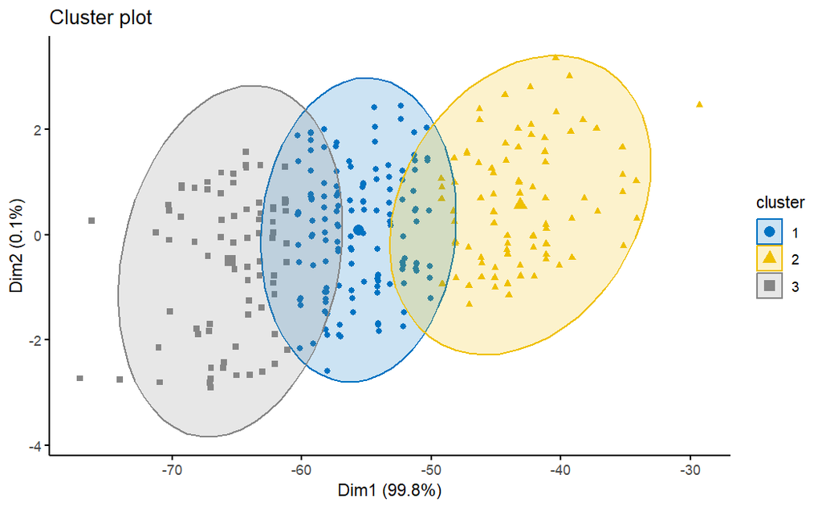

```r
fviz_cluster(list(data = dataset, cluster = km$cluster),
             ellipse.type = "norm", geom = "point", stand = FALSE,
             palette = "jco", ggtheme = theme_classic())
```

From the above results and the cluster representation we notice that there’s three clusters. First cluster contains 136 objects with total sum of square 1917.605. Second cluster contains 87 objects with total sum of square 1762.273. The third cluster contains 79 objects which is the smallest with total sum of square 1379.237.The value of the total sum of square indicate that the larger value means the larger separation so,the object in the first cluster are more separated than the objects in the other clusters and the high number of objects may have impacted this value since WSS is influenced by the number of observations.smallest WSS was for the third cluster that indicates that the objects are more compact.Also, we notice that there’s few outliers in the third cluster and only one outlier in the second cluster.

#### Average silhouette

```r
sil <- silhouette(km$cluster, dist(dataset))
rownames(sil) <- rownames(dataset)
```

|  | cluster | size | ave.sil.width |
| --- | --- | --- | --- |
| 1 | 1 | 136 | 0.43 |
| 2 | 2 | 87 | 0.53 |
| 3 | 3 | 79 | 0.46 |

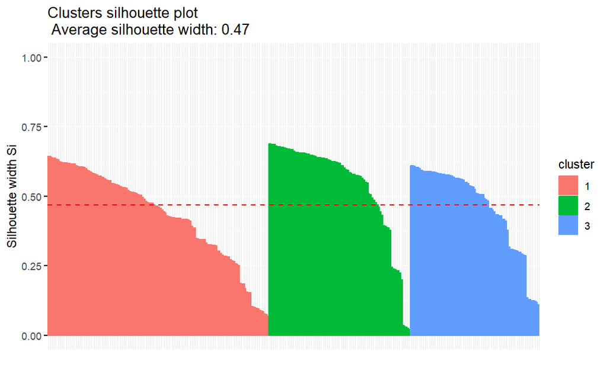

```r
fviz_silhouette(sil)
```

The average silhouette width is 0.47. This value indicates that, on average, the data points within the clusters are reasonably well-separated from each other and exhibit some similarity to the points in their neighboring clusters. However, it’s important to note that the interpretation of the silhouette width heavily depends on the specific data set and problem domain. Different data set may have different standards for what constitutes a good or bad silhouette width.

#### Total within-cluster-sum of square

```r
km$tot.withinss
```

```
[1] 5059.114
```

#### BCubed precision and recall

```r
cluster_assignments <- c(km$cluster)
ground_truth_labels <- c(dataBeforC$target)

data <- data.frame(cluster = cluster_assignments, label = ground_truth_labels)

# Function to calculate BCubed precision and recall
calculate_bcubed_metrics <- function(data) {
  n <- nrow(data)
  precision_sum <- 0
  recall_sum <- 0

  for (i in 1:n) {
    cluster <- data$cluster[i]
    label <- data$label[i]

# Count the number of items from the same category within the same cluster
same_category_same_cluster <- sum(data$label[data$cluster == cluster] == label)

# Count the total number of items in the same cluster
total_same_cluster <- sum(data$cluster == cluster)

# Count the total number of items with the same category
total_same_category <- sum(data$label == label)

# Calculate precision and recall for the current item and add them to the sums
precision_sum <- precision_sum + same_category_same_cluster /total_same_cluster
recall_sum <- recall_sum + same_category_same_cluster / total_same_category
  }

  # Calculate average precision and recall
  precision <- precision_sum / n
  recall <- recall_sum / n

  return(list(precision = precision, recall = recall))
}

# Calculate BCubed precision and recall
metrics <- calculate_bcubed_metrics(data)

# Extract precision and recall from the metrics
precision <- metrics$precision
recall <- metrics$recall

# Print the results
cat("BCubed Precision:", precision, "\n")
```

```
BCubed Precision: 0.5250096
```

```r
cat("BCubed Recall:", recall, "\n")
```

```
BCubed Recall: 0.3668491
```

The Bcubed precision value of 0.5250096 suggests that approximately 52.5% of the items within each cluster are correctly assigned to the same cluster as other similar items. This indicates that the clustering algorithm has some success in grouping similar items together. The Bcubed recall value of 0.3668491 indicates that around 36.7% of the items that should belong to the same cluster are indeed assigned to that cluster. This means that the algorithm is capturing only a fraction of the items that should be grouped together.

#### calculate k-mean k=4

```r
km <- kmeans(dataset, 4, iter.max = 140 , algorithm="Lloyd", nstart=100)
km
```

```
K-means clustering with 4 clusters of sizes 60, 73, 99, 70

Cluster means:
       age       sex        cp trestbps      chol   restecg   thalach     exang   oldpeak    slope        ca
1 66.51667 0.5833333 1.0333333 3.866667 0.4525487 0.4500000 0.5221374 0.3333333 0.1951613 1.316667 1.1000000
2 51.26027 0.7397260 1.0958904 3.356164 0.4007908 0.5342466 0.6245948 0.2739726 0.1212992 1.534247 0.5616438
3 58.41414 0.6868687 0.7474747 3.878788 0.4285813 0.5050505 0.5590254 0.4141414 0.2238514 1.262626 0.8282828
4 41.70000 0.7000000 1.0714286 3.057143 0.3589102 0.6142857 0.6980371 0.2571429 0.1154378 1.514286 0.1714286
      thal
1 2.283333
2 2.342466
3 2.414141
4 2.228571

Clustering vector:
```

[output cut: 31 more lines]

#### plot k-mean

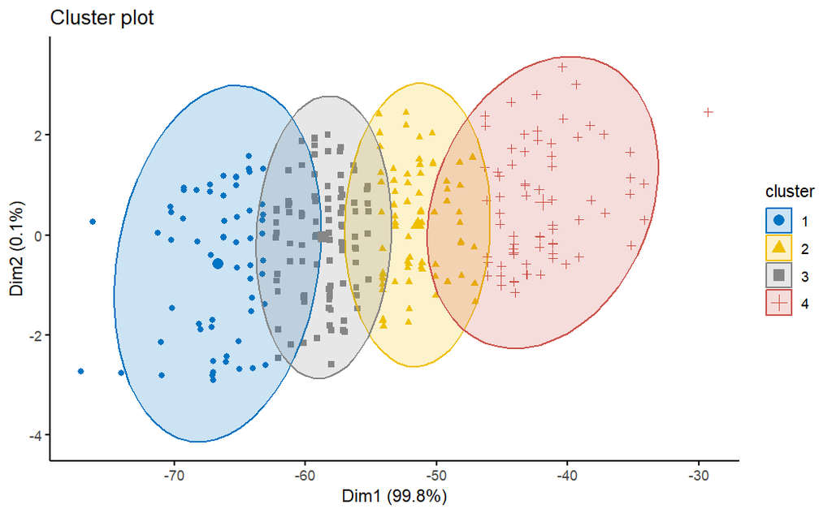

```r
fviz_cluster(list(data = dataset, cluster = km$cluster),
             ellipse.type = "norm", geom = "point", stand = FALSE,
             palette = "jco", ggtheme = theme_classic())
```

From the above results and the cluster representation we notice that there’s four clusters. First cluster contains 60 objects with total sum of square 930.4175. Second cluster contains 73 objects with total sum of square 677.2899. The third cluster contains 99 objects with total sum of square 907.0856. The fourth cluster contains 70 objects with total sum of square 1140.7632. The value of the total sum of square indicate that the larger value means the larger separation so,the object in the fourth cluster are more separated than the objects in the other clusters .smallest WSS was for the second cluster that indicates that the objects are more compact. Also, we notice that there’s few outliers in the first and the fourth clusters.

#### Average silhouette

```r
sil <- silhouette(km$cluster, dist(dataset))
rownames(sil) <- rownames(dataset)
```

|  | cluster | size | ave.sil.width |
| --- | --- | --- | --- |
| 1 | 1 | 60 | 0.39 |
| 2 | 2 | 73 | 0.39 |
| 3 | 3 | 99 | 0.37 |
| 4 | 4 | 70 | 0.47 |

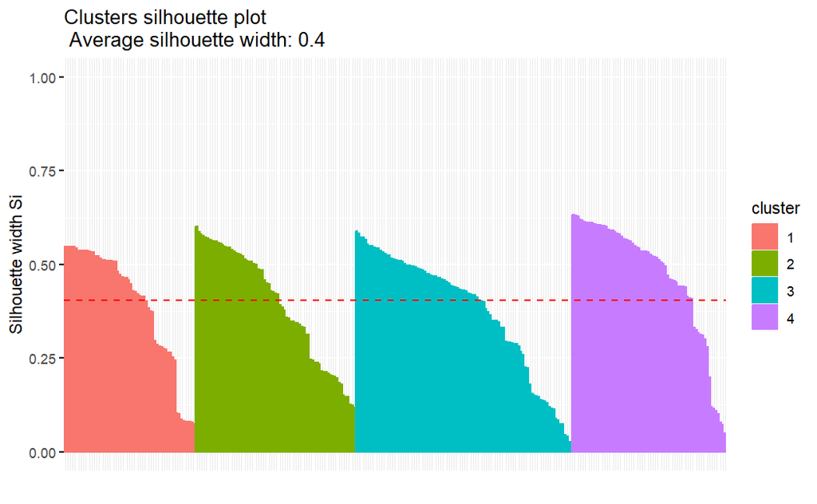

```r
fviz_silhouette(sil)
```

```r
km$tot.withinss
```

```
[1] 3655.556
```

The closer the points in a cluster are to the centroid, the better. A smaller distance indicates that the points are closer to the centroid, which is desirable. On the other hand, a larger distance signifies that the points are farther away from the centroid, which is less desirable.

```r
cluster_assignments <- c(km$cluster)
ground_truth_labels <- c(dataBeforC$target)

data <- data.frame(cluster = cluster_assignments, label = ground_truth_labels)

#Function to calculate BCubed precision and recall
calculate_bcubed_metrics <- function(data) {
  n <- nrow(data)
  precision_sum <- 0
  recall_sum <- 0

  for (i in 1:n) {
    cluster <- data$cluster[i]
    label <- data$label[i]

#Count the number of items from the same category within the same cluster
same_category_same_cluster <- sum(data$label[data$cluster == cluster] == label)

#Count the total number of items in the same cluster
total_same_cluster <- sum(data$cluster == cluster)

#Count the total number of items with the same category
total_same_category <- sum(data$label == label)

#Calculate precision and recall for the current item and add them to the sums
precision_sum <- precision_sum + same_category_same_cluster /total_same_cluster
recall_sum <- recall_sum + same_category_same_cluster / total_same_category
  }

  #Calculate average precision and recall
  precision <- precision_sum / n
  recall <- recall_sum / n

  return(list(precision = precision, recall = recall))
}

#Calculate BCubed precision and recall
metrics <- calculate_bcubed_metrics(data)

# Extract precision and recall from the metrics
precision <- metrics$precision
recall <- metrics$recall

#Print the results
cat("BCubed Precision:", precision, "\n")
```

```
BCubed Precision: 0.5502816
```

```r
cat("BCubed Recall:", recall, "\n")
```

```
BCubed Recall: 0.2854758
```

A precision of 0.5502816 suggests that approximately 55.0% of the items within the clusters are correctly assigned to the same cluster as other similar items. This indicates a moderate level of precision in the clustering results. A recall of 0.2854758 suggests that approximately 28.5% of the items that should be grouped together are correctly assigned to the same cluster. This indicates that the clustering algorithm captures only a fraction of the items that should belong to the same clusters

[output not shown]

### Findings:

In classification, We perform multiple decision trees using different partitioning splits and different attribute selection method we chose that had the best accuracy which is partitioning data into 80% training and 20% testing with information gain attribute selection. It had the highest accuracy (83.02%) indicating that the model had the best performance in predicting the correct class labels(targeted or not targeted to heart disease). In the other hand, the error rate was low (16.98%) since it equals (1-accuracy) and it shows the percent of incorrect predictions. For sensitivity it was (89.66%) which is high and tells that the model can well predict the positive instances (targeted to heart attack) and for specificity it was (75%) which is lower than the sensitivity and it tells how the model can predict the negative instances (not targeted to heart attack). Lastly, the precision was (81.25%) indicating the true positive instances over all that instances the model predicted as positive.

The decision tree had 6 pathes from the root to the leaves so, we will have 6 rules. Rules: 1- if number of major vessels (ca) <= 0 and exercise induced angina (exang) <= 0 and blood disorder (thal) <= 2 then target to have heart disease (target= 1) 2- if number of major vessels (ca) <= 0 and exercise induced angina (exang) <= 0 and blood disorder (thal) > 2 then target to have heart disease (target= 1) 3- if number of major vessels (ca) <= 0 and exercise induced angina (exang) > 0 and chest pain type (cp) <= 0 then not target to have heart disease (target= 0) 4- if number of major vessels (ca) <= 0 and exercise induced angina (exang) > 0 and chest pain type (cp) > 0 then target to have heart disease (target= 1) 5- if number of major vessels (ca) > 0 and chest pain type (cp) <= 0 then not target to have heart disease (target= 0) 6- if number of major vessels (ca) > 0 and chest pain type (cp) > 0 then target to have heart disease (target= 1). The decision tree illustrates that 4 attributes were used in predicting the class label which are (number of major vessels (ca), exercise induced angina (exang),blood disorder (thal) and chest pain type (cp)) where the other attributes had no effect in the class label prediction.

In Clustering, As previously mentioned, we used the K-means approach with three different values of K (K=2,3,4) to determine the optimal number of clusters. The average silhouette width, total within-cluster sum of squares, precision, and recall were used to evaluate the results. We came at the following findings after studying the data:

The average silhouette width dropped to 0.47 for K=3. The overall within-cluster sum of squares decreased to 5059.114, indicating that there is less diversity within the clusters than when K=2 was used. The accuracy and recall scores were 0.5250096 and 0.3668491, indicating a significantly reduced capacity to collect occurrences and identify all relevant points.

The average silhouette width dropped to 0.4 for K=4. The variance within the clusters is even lower than when K=3, as evidenced by the total within-cluster sum of squares dropping to 3655.556. With precision and recall values of 0.5502816 and 0.2854758, respectively, there was a greater capacity to precisely record instances, but a reduced capacity to recognize every pertinent point.

Both approaches (Classification and Clustering)were helpful for building models for our data set that can help in reaching our goal which is protecting people from heart attacks, but since our data set includes class label which is target, classification was considered the best option to predict the possibilities of having heart attack based on the attributes also the model had great accuracy.